# hugos_notebook

Hugo

2023-11-19

# Assignment 1

## Assignment 1.1

Import the data into R and divide it into training, validation and test sets (50%/25%/25%) by using the partitioning principle specified in the lecture slides.

```r
# 1.1
# Read data
digit_data <- read.csv("optdigits.csv", header=FALSE)

# Partition data (according to Oleg)
n = dim(digit_data)[1]

set.seed(12345)
id = sample(1:n, floor(n*0.5))
digits_train = digit_data[id,]
id1 = setdiff(1:n, id)

set.seed(12345)
id2 = sample(id1, floor(n*0.25))
digits_valid = digit_data[id2,]
id3 = setdiff(id1,id2)
digits_test = digit_data[id3,]
```

## Assignment 1.2

Use training data to fit 30-nearest neighbor classifier with function kknn() and kernel=”rectangular” from package kknn and estimate:

• Confusion matrices for the training and test data (use table())

• Misclassification errors for the training and test data

[output not shown]

```
## [1] "Confusion matrix for train data :"
```

```
##    pred
## obs   0   1   2   3   4   5   6   7   8   9
##   0 202   0   0   0   0   0   0   0   0   0
##   1   0 179  11   0   0   0   0   1   1   3
##   2   0   1 190   0   0   0   0   1   0   0
##   3   0   0   0 185   0   1   0   1   0   1
##   4   1   3   0   0 159   0   0   7   1   4
##   5   0   0   0   1   0 171   0   1   0   8
##   6   0   2   0   0   0   0 190   0   0   0
##   7   0   3   0   0   0   0   0 178   1   0
##   8   0  10   0   2   0   0   2   0 188   2
##   9   1   3   0   5   2   0   0   3   3 183
```

Confusion matrix and missclassification error for validation data :

```
##    pred
## obs  0  1  2  3  4  5  6  7  8  9
##   0 95  0  0  0  0  0  1  0  0  0
##   1  0 99  6  1  0  0  1  0  0  1
##   2  0  1 84  0  0  0  0  1  0  1
##   3  0  0  0 85  0  0  0  3  2  0
##   4  0  2  0  0 94  0  1  1  0  5
##   5  0  0  0  1  0 81  0  0  0 10
##   6  0  0  0  0  0  0 95  0  0  0
##   7  0  1  0  0  0  0  0 91  0  1
##   8  0  5  0  0  0  0  0  0 93  0
##   9  0  1  0  1  1  0  0  2  1 87
```

```
## Mean misclassification error for validation data : 0.0534  and individual misclassification error for each digit (0...9): 0.0104 0.0833 0.0345 0.0556 0.0874 0.1196 0 0.0215 0.051 0.0645
```

Confusion matrix and missclassification error for train data :

```
##    pred
## obs   0   1   2   3   4   5   6   7   8   9
##   0 202   0   0   0   0   0   0   0   0   0
##   1   0 179  11   0   0   0   0   1   1   3
##   2   0   1 190   0   0   0   0   1   0   0
##   3   0   0   0 185   0   1   0   1   0   1
##   4   1   3   0   0 159   0   0   7   1   4
##   5   0   0   0   1   0 171   0   1   0   8
##   6   0   2   0   0   0   0 190   0   0   0
##   7   0   3   0   0   0   0   0 178   1   0
##   8   0  10   0   2   0   0   2   0 188   2
##   9   1   3   0   5   2   0   0   3   3 183
```

```
## Mean isclassification error for train data : 0.045  and individual misclassification error for each digit (0...9) : 0 0.0821 0.0104 0.016 0.0914 0.0552 0.0104 0.022 0.0784 0.085
```

Comment on the quality of predictions for different digits and on the overall prediction quality.

## Assignment 1.3

Find any 2 cases of digit “8” in the training data which were easiest to classify and 3 cases that were hardest to classify (i.e. having highest and lowest probabilities of the correct class).

Reshape features for each of these cases as matrix 8x8 and visualize the corresponding digits (by using e.g. heatmap() function with parameters Colv=NA and Rowv=NA) and comment on whether these cases seem to be hard or easy to recognize visually.

2 cases of digit “8” in the training data which were easiest to classify:

[figure not shown]

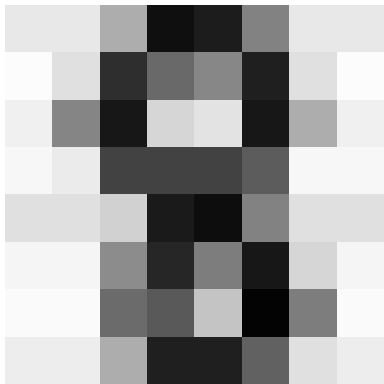

Those digits are quite easy to recognize visually, as they are quite clear and have a good contrast.

3 cases that were hardest to classify:

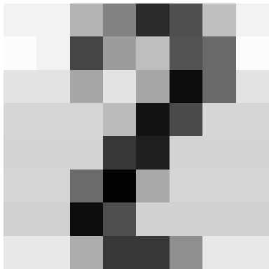

[figure not shown]

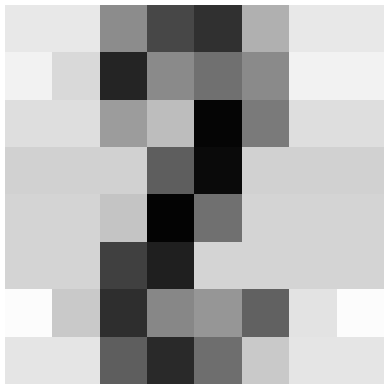

Those digits are quite hard to recognize visually, as they are quite messy and have a bad contrast. Some look more like “2”s .

## Assignment 1.4

Fit a K-nearest neighbor classifiers to the training data for different values of K K = 1,2, … , 30 and plot the dependence of the training and validation misclassification errors on the value of K (in the same plot). How does the model complexity change when K increases and how does it affect the training and validation errors? Report the optimal K K according to this plot. Finally, estimate the test error for the model having the optimal K, compare it with the training and validation errors and make necessary conclusions about the model quality.

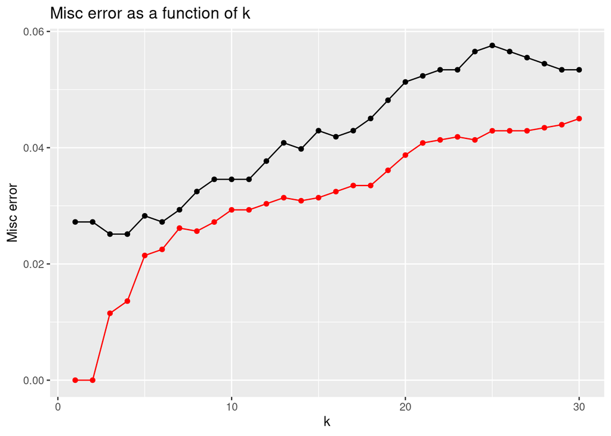

```
## [1] "Test error for k=3:  0.0240334378265413"
```

```
## [1] "Train error for k=3:  0.0115122972265829"
```

```
## [1] "Valid error for k=3:  0.025130890052356"
```

## Assignment 1.5

Fit K-nearest neighbor classifiers to the training data for different values of K K = 1,2, … , 30, compute the error for the validation data as cross-entropy (when computing log of probabilities add a small constant within log, e.g. 1e-15, to avoid numerical problems) and plot the dependence of the validation error on the value of K K.

Cross Entropy :
$$J(y,\hat{p}(y)) =
-\sum_{i=1}^{n}\sum_{m=1}^{M}I(y_i=C_m)*log(\hat{p}(y_i=C_m))$$

Plot:

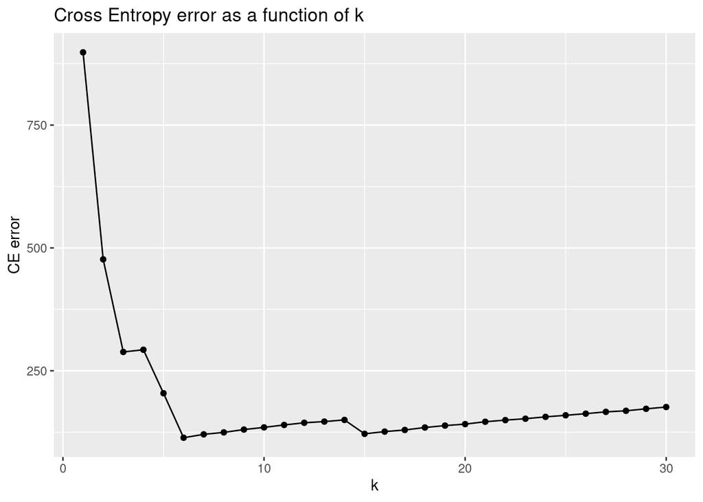

What is the optimal K K value here? Assuming that response has multinomial distribution, why might the cross-entropy be a more suitable choice of the error function than the misclassification error for this problem?

The optimal k value here is 6 as it has the lowest cross entropy error. The cross-entropy might be more suitable than the misclassification error because it is a more general error function that takes into account the probabilities of the predictions. The misclassification error only takes into account the number of misclassifications, which does not give a lot of insights into the quality of the predictions.